# Introduction to Assignment

This is the third Exercise of **188.995 Data-Oriented Programming Paradigms**

We are group 18, and consist of:

- Guillermo Alamán Requena, Matr. Nr: 11937906
- Michael Ferdinand Moser, Matr. Nr: 01123077
- Paul Joe Maliakel, Matr. Nr: 12012422
- Gunnar Sjúrðarson Knudsen, Matr. Nr: 12028205

In this task we were asked to choose one vaguely worded question, and then narrow the scope, figuring out how to get the data, before finally solving the question at hand. We chose **Question 21**, which contains:

- How does the use of various communication languages in countries change over time?
- Which languages grow and which disappear, and what are their characteristics?
- Are there other factors that correlate with the appearance or disappearance of languages?

We soon realized that the question as stated is far too broad, and we therefore had to limit it.

After having discussed amoung our groups, we came to the following plan:

## First draft

### Topic and Questions to answer

We've selected question 21, which is regarding how communication languages in countries change over time.

After having discussed the data available, and planned a workflow, we've decided to try to answer the questions:

- How has the English language changed in the past 100 years based on word frequencies, sentence length, ...?
- Can we find parallel developments between different genres of text?
- Can the publication year of a movie/article/whatever be predicted based on the text and its characteristics?

### Justification For Limit Of Scope

The sample questions stated in the task description are too broad, to be answered in a single 160 hour project.

- Lot's of issues, such as:
- Lack of census data;
- other changes such as phonetic, semantic and syntactic meanings;
- High correlation with e.g:
  - country population
  - age of speakers
  - ...
- What counts as a language?
  - dialect?
  - Mutually Intelligible?
- Political dimensions
- Multilingual people
- How do we check accuracy of the available data?
- ...

Historical data for language use is likely not available for most languages, as it's topics for great research to estimate merely historical populations - especially before 1850 or so. The evolution of languages are much less documented. Lack of census data overall, but other changes are even harder to gauge, such as phonetic, semantic, and syntactic meanings. Highly correlated with population of countries, but also with "hidden" correlations, such as age of speakers, ... Even dead languages can be revived.

What constitutes a language? Dialect? Mutually Intelligible? Also do not forget the political dimension, e.g. Croatian/Serbian really are just dialects of the same language but they want to keep separate. On the other end of this scheme the variant of Chinese spoken in Beijing may be drastically different from the Chinese spoken in other regions of the country, but still falls under the same "Chinese" umbrella to communicate unity.

How much is spoken? Should we consider people who studied a language as their second, third... language? If so, how well should be the command over the language for the person to count? A1/B1/C2 level? %How do we check accuracy of the available data?

### Workflow plan & Project management

- Outline the plan
  - Get, understand and clean data: articles/movie scripts/video transcripts over the years (see next section)
  - Train-test split: keeping proportion of publication years within the splits.
  - Preprocessing: text feature extraction, feature selection, scaling, etc. (Come back here if necessary)
  - Visualization: evolution of words over the years, word-clouds and other relevant characteristics.
  - Define evaluation metrics, train different models/parameters using CV and select best one for predictions.
  - Predict, conclude, report and publish notebook in Kaggle Kernel.
- How the work will be divided up between group members
  - Acquisition, cleaning and prepossessing of the data will be done commonly.
  - Each member of the group will train a model and report results using same evaluation metrics.
  - Jointly choose the best model and conclude.
  - Presentation, report and publishing will be also split.
- Timeline: To be defined after review meeting

### Data

Our goal is to get a dataset similar to:

| **Corpus** | **Year Published** | **Type** | ... |
| --- | --- | --- | --- |
| Text1 | 1976 | News | ... |
| Text2 | 1976 | Movie Script | ... |
| ... | ... | ... | ... |
| TextN | 2009 | Scientific Article | ... |

Feature extraction from texts will be performed to obtain appropriate features for modeling. To build a dataset like this one, we will rely on the following kind sources:

- \url{https://www.kaggle.com/asad1m9a9h6mood/news-articles} - News articles from 2015 until date.
- \url{https://www.kaggle.com/snapcrack/all-the-news} - 143000 articles from 15 American Publications.
- NLTK
- ...

## Second Draft

After having a preliminary meeting with Univ.Prof. Dr. Hanbury and Dipl.-Ing. Dr. Piroi, who gave great input, we decided to further limit out goal to only use Project Gutenberg as a datasource, and setting our hypothesis to see wether it was possible to generate a model that predicted the publication year/decade for a set of books.

## Pivoting Point

After having done a decent portion of work, we reached to the conclusion that our dataset was not suitable to solve the question we had original set out, and we were forced to pivot.

We discussed whether we wanted to change the goal from classifying, but as we were all quite interrested in a classification algorithm, and wanted to do proper NLP, we instead searched for another dataset.

## Language change in Icelandic Parliamentary Speeches

We found the dataset with all icelandic parliamentary speeches going back a century. This is further described in section 3. With this great dataset, our goal was to develop a model that could try to predict which decade a speech is from

# Estimating publication year from Project Gutenberg

This was the attempt at our first hypothesis. We import a large corpus of books from Project Gutenberg, and cleanse the data, so it's ready for machine learning

## Setup

We start by setting up all packages needed for the project

### Import packages

```python
from __future__ import absolute_import
from builtins import str
import os
from six import u

from os import listdir
from os.path import isfile, join

import nltk
import re
from operator import itemgetter
import pandas as pd
from functools import reduce

import random

pd.set_option('display.max_rows', None)

import math

from sklearn.feature_extraction.text import TfidfTransformer

from pprint import pprint
from time import time
import logging

from sklearn.datasets import fetch_20newsgroups
from sklearn.feature_extraction.text import CountVectorizer
from sklearn.feature_extraction.text import TfidfTransformer
from sklearn.linear_model import SGDClassifier
from sklearn.naive_bayes import MultinomialNB
from sklearn.model_selection import GridSearchCV
from sklearn.pipeline import Pipeline

from sklearn.feature_selection import SelectKBest, chi2
```

### Define Constants

Constant that are used in this part is also set

```python
file_path = "processedData"

TEXT_START_MARKERS = frozenset((u(_) for _ in (
    "*END*THE SMALL PRINT",
    "*** START OF THE PROJECT GUTENBERG",
    "*** START OF THIS PROJECT GUTENBERG",
    "This etext was prepared by",
    "E-text prepared by",
    "Produced by",
    "Distributed Proofreading Team",
    "Proofreading Team at http://www.pgdp.net",
    "http://gallica.bnf.fr)",
    "      http://archive.org/details/",
    "http://www.pgdp.net",
    "by The Internet Archive)",
    "by The Internet Archive/Canadian Libraries",
    "by The Internet Archive/American Libraries",
    "public domain material from the Internet Archive",
    "Internet Archive)",
    "Internet Archive/Canadian Libraries",
    "Internet Archive/American Libraries",
    "material from the Google Print project",
    "*END THE SMALL PRINT",
    "***START OF THE PROJECT GUTENBERG",
    "This etext was produced by",
    "*** START OF THE COPYRIGHTED",
    "The Project Gutenberg",
    "http://gutenberg.spiegel.de/ erreichbar.",
    "Project Runeberg publishes",
    "Beginning of this Project Gutenberg",
    "Project Gutenberg Online Distributed",
    "Gutenberg Online Distributed",
    "the Project Gutenberg Online Distributed",
    "Project Gutenberg TEI",
    "This eBook was prepared by",
    "http://gutenberg2000.de erreichbar.",
    "This Etext was prepared by",
    "This Project Gutenberg Etext was prepared by",
    "Gutenberg Distributed Proofreaders",
    "Project Gutenberg Distributed Proofreaders",
    "the Project Gutenberg Online Distributed Proofreading Team",
    "**The Project Gutenberg",
    "*SMALL PRINT!",
    "More information about this book is at the top of this file.",
    "tells you about restrictions in how the file may be used.",
    "l'authorization à les utilizer pour preparer ce texte.",
    "of the etext through OCR.",
    "*****These eBooks Were Prepared By Thousands of Volunteers!*****",
    "We need your donations more than ever!",
    " *** START OF THIS PROJECT GUTENBERG",
    "****     SMALL PRINT!",
    '["Small Print" V.',
    '      (http://www.ibiblio.org/gutenberg/',
    'and the Project Gutenberg Online Distributed Proofreading Team',
    'Mary Meehan, and the Project Gutenberg Online Distributed Proofreading',
    '                this Project Gutenberg edition.',
)))


TEXT_END_MARKERS = frozenset((u(_) for _ in (
    "*** END OF THE PROJECT GUTENBERG",
    "*** END OF THIS PROJECT GUTENBERG",
    "***END OF THE PROJECT GUTENBERG",
    "End of the Project Gutenberg",
    "End of The Project Gutenberg",
    "Ende dieses Project Gutenberg",
    "by Project Gutenberg",
    "End of Project Gutenberg",
    "End of this Project Gutenberg",
    "Ende dieses Projekt Gutenberg",
    "        ***END OF THE PROJECT GUTENBERG",
    "*** END OF THE COPYRIGHTED",
    "End of this is COPYRIGHTED",
    "Ende dieses Etextes ",
    "Ende dieses Project Gutenber",
    "Ende diese Project Gutenberg",
    "**This is a COPYRIGHTED Project Gutenberg Etext, Details Above**",
    "Fin de Project Gutenberg",
    "The Project Gutenberg Etext of ",
    "Ce document fut presente en lecture",
    "Ce document fut présenté en lecture",
    "More information about this book is at the top of this file.",
    "We need your donations more than ever!",
    "END OF PROJECT GUTENBERG",
    " End of the Project Gutenberg",
    " *** END OF THIS PROJECT GUTENBERG",
)))


LEGALESE_START_MARKERS = frozenset((u(_) for _ in (
    "<<THIS ELECTRONIC VERSION OF",
)))


LEGALESE_END_MARKERS = frozenset((u(_) for _ in (
    "SERVICE THAT CHARGES FOR DOWNLOAD",
)))

TITLE_MARKERS = frozenset((u(_) for _ in (
    "Title:",
)))

AUTHOR_MARKERS = frozenset((u(_) for _ in (
    "Author:",
)))
DATE_MARKERS = frozenset((u(_) for _ in (
    "Release Date:","Release Date:"
)))
LANGUAGE_MARKERS = frozenset((u(_) for _ in (
    "Language:",
)))
ENCODING_MARKERS = frozenset((u(_) for _ in (
    "Character set encoding:",
)))
```

## Importing the data

This is a very rough first draft at importing and cleansing the data. Solution is heavily inspired by https://gist.github.com/mbforbes/cee3fd5bb3a797b059524fe8c8ccdc2b

### Getting the content

Start by downloading the repository of (english) books. This is done in bash. Only tested on Ubuntu, but mac should work the same

```
wget -m -H -nd "http://www.gutenberg.org/robot/harvest?filetypes[]=txt&langs[]=en"

                http://www.gutenberg.org/robot/harvest?offset=40532&filetypes[]=txt&langs[]=en
```

Takes a few hours to run, and is stored in a folder called rawContent. This is then copied to another folder, and we can start to clean up the mess

First we delete some dublications of the same books:

```
ls | grep "\-8.zip" | xargs rm
ls | grep "\-0.zip" | xargs rm
```

We can then unzip the files, and remove the zip files

```
unzip "*zip"
rm *.zip
```

Next we take care of some nested foldering

```
mv */*.txt ./
```

And finally, we remove all rubbish that isn't a real book:

```
ls | grep -v "\.txt" | xargs rm -rf
```

### Data Cleansing

As the data is not given in a computer-friendly format, a lot of string operations are needed

#### Read a single file

```python
def read_file(file_name):
    file = open(file_name, encoding="ISO-8859-1")
    file_content = file.read()

    lines = file_content.splitlines()
    sep = str(os.linesep)

    # Initialize results for single book
    content_lines = []
    i = 0
    footer_found = False
    ignore_section = False

    title = ""
    author = ""
    date = ""
    language = ""
    encoding = ""
    year = 0

    # Reset flags for each book
    title_found = False
    author_found = False
    date_found = False
    language_found = False
    encoding_found = False

    for line in lines:
            reset = False

            #print(line)
            if i <= 600:
                # Shamelessly stolen
                if any(line.startswith(token) for token in TEXT_START_MARKERS):
                    reset = True

                # Extract Metadata
                if title_found == False:
                    if any(line.startswith(token) for token in TITLE_MARKERS):
                        title_found = True
                        title = line
                if author_found == False:
                    if any(line.startswith(token) for token in AUTHOR_MARKERS):
                        author_found = True
                        author = line
                if date_found == False:
                    if any(line.startswith(token) for token in DATE_MARKERS):
                        date_found = True
                        date = line
                        year = int(re.findall(r'\d{4}', date)[0])
                if language_found == False:
                    if any(line.startswith(token) for token in LANGUAGE_MARKERS):
                        language_found = True
                        language = line
                if encoding_found == False:
                    if any(line.startswith(token) for token in ENCODING_MARKERS):
                        encoding_found = True
                        encoding = line

                # More theft from above
                if reset:
                    content_lines = []
                    continue

            # I feel like a criminal by now. Guess what? Also stolen
            if i >= 100:
                if any(line.startswith(token) for token in TEXT_END_MARKERS):
                    footer_found = True

                if footer_found:
                    break

            if any(line.startswith(token) for token in LEGALESE_START_MARKERS):
                ignore_section = True
                continue
            elif any(line.startswith(token) for token in LEGALESE_END_MARKERS):
                ignore_section = False
                continue

            if not ignore_section:
                if line != "": # Screw the blank lines
                    content_lines.append(line.rstrip(sep))
                i += 1

            sep.join(content_lines)

    # Do more cleaning
    for token in TITLE_MARKERS:
        title = title.replace(token, '').lstrip().rstrip()
    for token in AUTHOR_MARKERS:
        author = author.replace(token, '').lstrip().rstrip()
    for token in LANGUAGE_MARKERS:
        language = language.replace(token, '').lstrip().rstrip()
    for token in DATE_MARKERS:
        date = date.replace(token, '').lstrip().rstrip()
    for token in ENCODING_MARKERS:
        encoding = encoding.replace(token, '').lstrip().rstrip()
    return title, author, date, year, language, encoding, content_lines
```

#### Return list of all words

Currently quite an empty function. However, I assume that some cleaning of cases etc. will be done here

```python
def get_words(content_lines):
    all_text_lower = " ".join(content_lines).lower()
    words = re.findall(r'(\b[A-Za-z][a-z]{2,9}\b)', all_text_lower)

    # Do more cleansing. E.g. cases and stuff

    return words
```

## Statistics

We start by doing some exploratory data analysis, to see how well our scraping works

### First attempt

Trying a simple word frequency

```python
def get_word_frequencies(words):
    frequency = {}
    for word in words:
        count = frequency.get(word,0)
        frequency[word] = count + 1

    word_count = len(words)
    unique_word_count = 0
    word_list = []
    word_list_count = []
    for key, value in reversed(sorted(frequency.items(), key = itemgetter(1))):
        word_list.append(key)
        word_list_count.append(value)
        unique_word_count = unique_word_count + 1

    word_list_freq = [freq / word_count for freq in word_list_count]

    word_freq = pd.DataFrame(list(zip(word_list, word_list_count, word_list_freq))
                             , columns = ['Word', 'count', 'freq'])

    word_freq['rank'] = word_freq['count'].rank(ascending = False, method="dense")

    return(word_freq, unique_word_count)
```

### Read all files, and do preprocessing

Well... Only ten files currently

```python
# Get all filenames
files = [f for f in listdir(file_path) if isfile(join(file_path, f))]
files = list(filter(lambda file: file[0].isdigit(), files))
random.shuffle(files)


# Do only subset
files = files[0:10]

list_of_file = []
list_of_title = []
list_of_author = []
list_of_date = []
list_of_year = []
list_of_language = []
list_of_encoding = []
list_of_word_count = []
list_of_unique_word_count = []
list_of_word_frequencies = []
iter_ = 0

for file in files:
    # Read in basic information from file
    title, author, date, year, language, encoding, content_lines = read_file(file_path + "/" + file)
    line_count = len(content_lines)

    # Not sure if we want this for later:
    #content_all = " ".join(content_lines)

    # Split into words (and do various cleaning)
    words = get_words(content_lines)
    word_count = len(words)

    # First analysis, but should do something proper
    word_frequencies_table, unique_word_count = get_word_frequencies(words)

    # Append to results
    list_of_file.append(file)
    list_of_title.append(title)
    list_of_author.append(author)
    list_of_date.append(date)
    list_of_year.append(year)
    list_of_language.append(language)
    list_of_encoding.append(encoding)
    list_of_word_count.append(word_count)
    list_of_unique_word_count.append(unique_word_count)
    list_of_word_frequencies.append(word_frequencies_table)


    # Show basic information
    #print(iter_)
    iter_ = iter_ + 1
    #print("################################")
    #print("################################")
    #print("Filename: " + str(file))
    #print("Title: " + str(title))
    #print("Author(s): " + str(author))
    #print("Date: " + str(date))
    #print("Year: " + str(year))
    #print("Language: " + str(language))
    #print("Encoding: " + str(encoding))
    #print("################################")
    #print("Words in book: " + str(word_count))
    #print("Unique words in book: " + str(unique_word_count))
    #print("################################")
    #print(word_frequencies_table)

# Feel free to change to dict? list? separate files?
## nested dataframes works, but looks super ungly when printing
### Fuck it - This is tooo useless killing it again
#all_res = pd.DataFrame(list(zip(list_of_file
#                                , list_of_title
#                                , list_of_author
#                                , list_of_date
#                                , list_of_language
#                                , list_of_encoding
#                                , list_of_word_count
#                                , list_of_unique_word_count
#                                , list_of_word_frequencies
#                                ))
#                             , columns = ['file'
#                                          , 'title'
#                                          , 'author'
#                                          , 'date'
#                                          , 'language'
#                                          , 'encoding'
#                                          , 'word_count'
#                                          , 'unique_word_count'
#                                          , 'word_frequencies'
#                                         ]
#                      )
```

### Compare Word ranking between titles

This is our first attemt at seeing how the ranking of words change between titles. Idea is to see that the zipf-distribution changes as time passes buy

```python
list_count= []
list_freq = []
list_rank = []


col_names = list_of_title.copy()
col_names.insert(0,'Word')

for df in list_of_word_frequencies:
    list_count.append(df[['Word', 'count']])
    list_freq.append(df[['Word', 'freq']])
    list_rank.append(df[['Word', 'rank']])

df_count = reduce(lambda left, right: pd.merge(left, right, on="Word", how='outer'), list_count)
df_count.columns = col_names
df_count['Sum'] = df_count.drop('Word', axis=1).apply(lambda x: x.sum(), axis=1)
df_count = df_count.sort_values(ascending = False, by=['Sum'])

df_freq = reduce(lambda left, right: pd.merge(left, right, on="Word", how='outer'), list_freq)
df_freq.columns = col_names
df_freq['Avg'] = df_freq.drop('Word', axis=1).apply(lambda x: x.mean(), axis=1)
df_freq = df_freq.sort_values(ascending = False, by=['Avg'])

df_rank = reduce(lambda left, right: pd.merge(left, right, on="Word", how='outer'), list_rank)
df_rank.columns = col_names
df_rank['Avg'] = df_rank.drop('Word', axis=1).apply(lambda x: x.mean(), axis=1)
df_rank = df_rank.sort_values(by=['Avg'])
```

```python
df_rank.head(30)
```

|  | Word | Hal Kenyon Disappears | The Great Events by Famous Historians, v. 13 | Mystic Christianity | Memoir | The Story of a Fierce Bad Rabbit | The Stranger | Harper's Young People, July 20, 1880 | The Borghesi Astronomical Clock in the Museum of History and Technology | Genera of Leptodactylid Frogs in Mexico | The Supplies for the Confederate Army | Avg |
| --- | --- | --- | --- | --- | --- | --- | --- | --- | --- | --- | --- | --- |
| 0 | the | 1.0 | 1.0 | 1.0 | 1.0 | 1.0 | 1.0 | 1.0 | 1.0 | 1.0 | 1.0 | 1.000000 |
| 1 | and | 2.0 | 2.0 | 2.0 | 2.0 | 3.0 | 2.0 | 2.0 | 2.0 | 2.0 | 2.0 | 2.100000 |
| 15028 | ltd | NaN | NaN | NaN | NaN | 5.0 | NaN | NaN | NaN | NaN | NaN | 5.000000 |
| 3 | that | 4.0 | 5.0 | 3.0 | 4.0 | NaN | 5.0 | 4.0 | 4.0 | 15.0 | 5.0 | 5.444444 |
| 15030 | warne | NaN | NaN | NaN | NaN | 6.0 | NaN | NaN | NaN | NaN | NaN | 6.000000 |
| 15029 | carrot | NaN | NaN | NaN | NaN | 6.0 | NaN | NaN | NaN | NaN | NaN | 6.000000 |
| 17110 | tubercles | NaN | NaN | NaN | NaN | NaN | NaN | NaN | NaN | 6.0 | NaN | 6.000000 |
| 15040 | potter | NaN | NaN | NaN | NaN | 7.0 | NaN | NaN | NaN | NaN | NaN | 7.000000 |
| 15032 | skinner | NaN | NaN | NaN | NaN | 7.0 | NaN | NaN | NaN | NaN | NaN | 7.000000 |
| 15035 | hides | NaN | NaN | NaN | NaN | 7.0 | NaN | NaN | NaN | NaN | NaN | 7.000000 |
| 15031 | carmelite | NaN | NaN | NaN | NaN | 7.0 | NaN | NaN | NaN | NaN | NaN | 7.000000 |
| 15037 | scratches | NaN | NaN | NaN | NaN | 7.0 | NaN | NaN | NaN | NaN | NaN | 7.000000 |
| 15038 | berne | NaN | NaN | NaN | NaN | 7.0 | NaN | NaN | NaN | NaN | NaN | 7.000000 |
| 15039 | signatory | NaN | NaN | NaN | NaN | 7.0 | NaN | NaN | NaN | NaN | NaN | 7.000000 |
| 15034 | shoots | NaN | NaN | NaN | NaN | 7.0 | NaN | NaN | NaN | NaN | NaN | 7.000000 |
| 15033 | peeps | NaN | NaN | NaN | NaN | 7.0 | NaN | NaN | NaN | NaN | NaN | 7.000000 |
| 15041 | beatrix | NaN | NaN | NaN | NaN | 7.0 | NaN | NaN | NaN | NaN | NaN | 7.000000 |
| 17111 | genus | NaN | NaN | NaN | NaN | NaN | NaN | NaN | NaN | 7.0 | NaN | 7.000000 |
| 17112 | maxillary | NaN | NaN | NaN | NaN | NaN | NaN | NaN | NaN | 8.0 | NaN | 8.000000 |
| 17113 | frogs | NaN | NaN | NaN | NaN | NaN | NaN | NaN | NaN | 8.0 | NaN | 8.000000 |
| 2 | was | 3.0 | 3.0 | 5.0 | 5.0 | NaN | 27.0 | 3.0 | 8.0 | 23.0 | 3.0 | 8.888889 |
| 11 | for | 12.0 | 10.0 | 7.0 | 6.0 | 7.0 | 9.0 | 7.0 | 8.0 | 25.0 | 4.0 | 9.500000 |
| 10 | with | 11.0 | 6.0 | 11.0 | 10.0 | 6.0 | 13.0 | 9.0 | 6.0 | 14.0 | 11.0 | 9.700000 |
| 16277 | borghesi | NaN | NaN | NaN | NaN | NaN | NaN | NaN | 10.0 | NaN | NaN | 10.000000 |
| 17114 | inguinal | NaN | NaN | NaN | NaN | NaN | NaN | NaN | NaN | 10.0 | NaN | 10.000000 |
| 4 | his | 5.0 | 4.0 | 4.0 | 15.0 | 4.0 | 11.0 | 14.0 | 9.0 | 27.0 | 15.0 | 10.800000 |
| 17116 | genera | NaN | NaN | NaN | NaN | NaN | NaN | NaN | NaN | 11.0 | NaN | 11.000000 |
| 17115 | terminal | NaN | NaN | NaN | NaN | NaN | NaN | NaN | NaN | 11.0 | NaN | 11.000000 |
| 16278 | bertolla | NaN | NaN | NaN | NaN | NaN | NaN | NaN | 12.0 | NaN | NaN | 12.000000 |
| 17 | not | 18.0 | 15.0 | 12.0 | 20.0 | NaN | 4.0 | 11.0 | 23.0 | 4.0 | 9.0 | 12.888889 |

```python
#df_freq['Avg'] = df_freq.drop('Word', axis=1).apply(lambda x: x.mean(), axis=1)
df_freq = df_freq.sort_values(ascending = False, by=['Avg'])

df_freq.head(20)
```

|  | Word | Hal Kenyon Disappears | The Great Events by Famous Historians, v. 13 | Mystic Christianity | Memoir | The Story of a Fierce Bad Rabbit | The Stranger | Harper's Young People, July 20, 1880 | The Borghesi Astronomical Clock in the Museum of History and Technology | Genera of Leptodactylid Frogs in Mexico | The Supplies for the Confederate Army | Avg |
| --- | --- | --- | --- | --- | --- | --- | --- | --- | --- | --- | --- | --- |
| 0 | the | 0.095039 | 0.109884 | 0.121139 | 0.079243 | 0.078431 | 0.048657 | 0.076009 | 0.141561 | 0.067406 | 0.095608 | 0.091298 |
| 1 | and | 0.043636 | 0.043128 | 0.051943 | 0.045662 | 0.045752 | 0.032568 | 0.049199 | 0.037406 | 0.061197 | 0.038884 | 0.044937 |
| 15027 | rabbit | NaN | NaN | NaN | NaN | 0.065359 | 0.000078 | NaN | NaN | NaN | NaN | 0.032719 |
| 15028 | ltd | NaN | NaN | NaN | NaN | 0.019608 | NaN | NaN | NaN | NaN | NaN | 0.019608 |
| 2 | was | 0.022507 | 0.018942 | 0.012008 | 0.014935 | NaN | 0.004139 | 0.014202 | 0.008240 | 0.002217 | 0.032136 | 0.014370 |
| 3 | that | 0.014155 | 0.013064 | 0.019161 | 0.017314 | NaN | 0.012496 | 0.011593 | 0.010730 | 0.005765 | 0.014296 | 0.013175 |
| 15030 | warne | NaN | NaN | NaN | NaN | 0.013072 | NaN | NaN | NaN | NaN | NaN | 0.013072 |
| 15029 | carrot | NaN | NaN | NaN | NaN | 0.013072 | NaN | NaN | NaN | NaN | NaN | 0.013072 |
| 17110 | tubercles | NaN | NaN | NaN | NaN | NaN | NaN | NaN | NaN | 0.012417 | NaN | 0.012417 |
| 4 | his | 0.013539 | 0.016020 | 0.016826 | 0.008181 | 0.032680 | 0.009763 | 0.006087 | 0.008003 | 0.000443 | 0.005833 | 0.011737 |
| 17111 | genus | NaN | NaN | NaN | NaN | NaN | NaN | NaN | NaN | 0.010643 | NaN | 0.010643 |
| 17113 | frogs | NaN | NaN | NaN | NaN | NaN | NaN | NaN | NaN | 0.010200 | NaN | 0.010200 |
| 17112 | maxillary | NaN | NaN | NaN | NaN | NaN | NaN | NaN | NaN | 0.010200 | NaN | 0.010200 |
| 11 | for | 0.008528 | 0.008495 | 0.008636 | 0.013318 | 0.006536 | 0.011325 | 0.009347 | 0.008240 | 0.001330 | 0.018641 | 0.009440 |
| 12 | this | 0.007385 | 0.007406 | 0.008580 | 0.009989 | 0.032680 | 0.010778 | 0.002536 | 0.008299 | 0.001330 | 0.004346 | 0.009333 |
| 10 | with | 0.008968 | 0.010666 | 0.007487 | 0.010369 | 0.013072 | 0.008747 | 0.008188 | 0.009722 | 0.006652 | 0.007434 | 0.009130 |
| 17 | not | 0.005392 | 0.005996 | 0.007375 | 0.005993 | NaN | 0.013824 | 0.007826 | 0.003913 | 0.018182 | 0.008920 | 0.008602 |
| 17114 | inguinal | NaN | NaN | NaN | NaN | NaN | NaN | NaN | NaN | 0.008426 | NaN | 0.008426 |
| 17116 | genera | NaN | NaN | NaN | NaN | NaN | NaN | NaN | NaN | 0.007982 | NaN | 0.007982 |
| 17115 | terminal | NaN | NaN | NaN | NaN | NaN | NaN | NaN | NaN | 0.007982 | NaN | 0.007982 |

```python
df_count.head(20)
```

|  | Word | Hal Kenyon Disappears | The Great Events by Famous Historians, v. 13 | Mystic Christianity | Memoir | The Story of a Fierce Bad Rabbit | The Stranger | Harper's Young People, July 20, 1880 | The Borghesi Astronomical Clock in the Museum of History and Technology | Genera of Leptodactylid Frogs in Mexico | The Supplies for the Confederate Army | Sum |
| --- | --- | --- | --- | --- | --- | --- | --- | --- | --- | --- | --- | --- |
| 0 | the | 3243.0 | 13012.0 | 6537.0 | 833.0 | 12.0 | 623.0 | 1049.0 | 2388.0 | 152.0 | 836.0 | 28685.0 |
| 1 | and | 1489.0 | 5107.0 | 2803.0 | 480.0 | 7.0 | 417.0 | 679.0 | 631.0 | 138.0 | 340.0 | 12091.0 |
| 2 | was | 768.0 | 2243.0 | 648.0 | 157.0 | NaN | 53.0 | 196.0 | 139.0 | 5.0 | 281.0 | 4490.0 |
| 3 | that | 483.0 | 1547.0 | 1034.0 | 182.0 | NaN | 160.0 | 160.0 | 181.0 | 13.0 | 125.0 | 3885.0 |
| 4 | his | 462.0 | 1897.0 | 908.0 | 86.0 | 5.0 | 125.0 | 84.0 | 135.0 | 1.0 | 51.0 | 3754.0 |
| 10 | with | 306.0 | 1263.0 | 404.0 | 109.0 | 2.0 | 112.0 | 113.0 | 164.0 | 15.0 | 65.0 | 2553.0 |
| 11 | for | 291.0 | 1006.0 | 466.0 | 140.0 | 1.0 | 145.0 | 129.0 | 139.0 | 3.0 | 163.0 | 2483.0 |
| 5 | had | 364.0 | 1171.0 | 360.0 | 93.0 | NaN | 26.0 | 111.0 | 68.0 | NaN | 114.0 | 2307.0 |
| 112 | which | 45.0 | 1081.0 | 510.0 | 126.0 | NaN | 35.0 | 62.0 | 172.0 | 4.0 | 66.0 | 2101.0 |
| 12 | this | 252.0 | 877.0 | 463.0 | 105.0 | 5.0 | 138.0 | 35.0 | 140.0 | 3.0 | 38.0 | 2056.0 |
| 9 | but | 307.0 | 721.0 | 412.0 | 46.0 | 1.0 | 151.0 | 141.0 | 54.0 | 10.0 | 85.0 | 1928.0 |
| 16 | from | 186.0 | 829.0 | 409.0 | 60.0 | NaN | 80.0 | 56.0 | 195.0 | 18.0 | 66.0 | 1899.0 |
| 13 | were | 241.0 | 1041.0 | 253.0 | 92.0 | NaN | 30.0 | 74.0 | 37.0 | 2.0 | 122.0 | 1892.0 |
| 17 | not | 184.0 | 710.0 | 398.0 | 63.0 | NaN | 177.0 | 108.0 | 66.0 | 41.0 | 78.0 | 1825.0 |
| 6 | they | 360.0 | 638.0 | 314.0 | 202.0 | NaN | 41.0 | 135.0 | 38.0 | NaN | 36.0 | 1764.0 |
| 21 | their | 164.0 | 865.0 | 306.0 | 123.0 | NaN | 32.0 | 37.0 | 50.0 | 5.0 | 30.0 | 1612.0 |
| 24 | have | 150.0 | 431.0 | 247.0 | 101.0 | NaN | 157.0 | 81.0 | 77.0 | 16.0 | 47.0 | 1307.0 |
| 18 | all | 184.0 | 520.0 | 276.0 | 62.0 | 2.0 | 61.0 | 76.0 | 53.0 | 8.0 | 49.0 | 1291.0 |
| 14 | him | 216.0 | 436.0 | 354.0 | 33.0 | 1.0 | 86.0 | 72.0 | 16.0 | NaN | 33.0 | 1247.0 |
| 7 | you | 352.0 | 127.0 | 121.0 | 3.0 | NaN | 385.0 | 98.0 | 64.0 | NaN | 32.0 | 1182.0 |

## Second testing

This definately needs some proper refactoring, but Was curious whether we get anything decent from reading a bunch of random books in

Requires an additional folder "decades" in the root directory

```python
# Get all filenames
files = [f for f in listdir(file_path) if isfile(join(file_path, f))]

# Do only subset
## Is done for 5000 files already, so set down to 20 to increase performance. 5000 books are currently stored in the file
files = files[0:20]


counter = 0
for file in files:
    counter = counter + 1
    # Read in basic information from file
    title, author, date, year, language, encoding, content_lines = read_file(file_path + "/" + file)
    #line_count = len(content_lines)
    decade = math.floor(year / 10) * 10
    decade_file = "decades/" + str(decade) + ".txt"
    content_all = " ".join(content_lines)

    if os.path.exists(decade_file):
        append_write = 'a' # append if already exists
    else:
        append_write = 'w' # make a new file if not

    fileWriter = open(decade_file,append_write)
    fileWriter.write(content_all + '\n')
    fileWriter.close()
```

### Read in from the decades files, and see the distributions

```python
# Get all filenames
files = [f for f in listdir("decades") if isfile(join("decades", f))]
print(files)
files.sort(reverse=True)


col_names = []
col_names.append("Word")

tables = []

for file_name in files:
    print(file_name)

    file = open("decades/" + file_name, encoding="ISO-8859-1")
    file_content = file.read()

    # Split into words (and do various cleaning)
    all_text_lower = file_content.lower()
    words = re.findall(r'(\b[A-Za-z][a-z]{2,9}\b)', all_text_lower)

    # First analysis, but should do something proper
    word_frequencies_table, unique_word_count = get_word_frequencies(words)
    tables.append(word_frequencies_table)
    col_names.append(file_name)
```

```
['00.txt', '0.txt', '2010.txt', '2000.txt', '2020.txt', '1990.txt']
2020.txt
2010.txt
2000.txt
1990.txt
00.txt
0.txt
```

### Preliminary Conclusion

We see that even though the books are quite old, no decade prior to 1990s is found.

This is when we found out that the "year" that's registered in the dataset is the upload-date.

Haven gotten this far, we however decided to see if we could find a pattern in this

### Compare ranking between upload-decades

```python
list_count= []
list_freq = []
list_rank = []

for df in tables:
    #list_count.append(df[['Word', 'count']])
    #list_freq.append(df[['Word', 'freq']])
    list_rank.append(df[['Word', 'rank']])

#df_count = reduce(lambda left, right: pd.merge(left, right, on="Word", how='outer'), list_count)
#df_count.columns = col_names

#df_freq = reduce(lambda left, right: pd.merge(left, right, on="Word", how='outer'), list_freq)
#df_freq.columns = col_names

df_rank = reduce(lambda left, right: pd.merge(left, right, on="Word", how='outer'), list_rank)
df_rank.columns = col_names
```

```python
df_rank.head(100)
```

|  | Word | 2020.txt | 2010.txt | 2000.txt | 1990.txt | 00.txt | 0.txt |
| --- | --- | --- | --- | --- | --- | --- | --- |
| 0 | the | 1.0 | 1.0 | 1.0 | 1.0 | 1.0 | 1.0 |
| 1 | and | 2.0 | 2.0 | 2.0 | 2.0 | 2.0 | 2.0 |
| 2 | that | 3.0 | 3.0 | 3.0 | 3.0 | 4.0 | 3.0 |
| 3 | was | 4.0 | 4.0 | 4.0 | 4.0 | 23.0 | 5.0 |
| 4 | you | 5.0 | 9.0 | 8.0 | 5.0 | 163.0 | 19.0 |
| 5 | with | 6.0 | 6.0 | 6.0 | 7.0 | 3.0 | 6.0 |
| 6 | for | 7.0 | 7.0 | 7.0 | 11.0 | 13.0 | 8.0 |
| 7 | his | 8.0 | 5.0 | 5.0 | 6.0 | 5.0 | 4.0 |
| 8 | not | 9.0 | 10.0 | 11.0 | 12.0 | 11.0 | 9.0 |
| 9 | had | 10.0 | 8.0 | 9.0 | 10.0 | 40.0 | 14.0 |
| 10 | but | 11.0 | 11.0 | 10.0 | 13.0 | 72.0 | 10.0 |
| 11 | which | 12.0 | 12.0 | 14.0 | 22.0 | 82.0 | 7.0 |
| 12 | they | 13.0 | 17.0 | 15.0 | 16.0 | 58.0 | 21.0 |
| 13 | from | 14.0 | 15.0 | 18.0 | 21.0 | 25.0 | 15.0 |
| 14 | were | 15.0 | 21.0 | 21.0 | 20.0 | 81.0 | 22.0 |
| 15 | have | 16.0 | 16.0 | 16.0 | 18.0 | 22.0 | 11.0 |
| 16 | this | 17.0 | 14.0 | 17.0 | 15.0 | 8.0 | 13.0 |
| 17 | are | 18.0 | 20.0 | 23.0 | 27.0 | 37.0 | 16.0 |
| 18 | she | 19.0 | 18.0 | 13.0 | 9.0 | 65.0 | 47.0 |
| 19 | all | 20.0 | 19.0 | 20.0 | 17.0 | 15.0 | 12.0 |
| 20 | their | 21.0 | 24.0 | 25.0 | 26.0 | 21.0 | 30.0 |
| 21 | him | 22.0 | 22.0 | 19.0 | 14.0 | 28.0 | 20.0 |
| 22 | her | 23.0 | 13.0 | 12.0 | 8.0 | 20.0 | 33.0 |
| 23 | its | 24.0 | 40.0 | 52.0 | 98.0 | 68.0 | 67.0 |
| 24 | one | 25.0 | 23.0 | 22.0 | 25.0 | 17.0 | 28.0 |
| 25 | there | 26.0 | 25.0 | 24.0 | 23.0 | 37.0 | 32.0 |
| 26 | them | 27.0 | 28.0 | 28.0 | 32.0 | 55.0 | 38.0 |
| 27 | what | 28.0 | 33.0 | 32.0 | 24.0 | 56.0 | 24.0 |
| 28 | has | 29.0 | 38.0 | 44.0 | 46.0 | 176.0 | 40.0 |
| 29 | been | 30.0 | 29.0 | 31.0 | 33.0 | 30.0 | 23.0 |

[output cut: 70 more lines]

## Trying to fit models to predict

### Read in files

```python
file_contents = []
targets = []

files = [f for f in listdir(file_path) if isfile(join(file_path, f))]
files = list(filter(lambda file: file[0].isdigit(), files))
random.shuffle(files)

targets_=['70','80','90','00','10']
iter_ = 0

for f in files[:120]:
    file = open("processedData/" + f, encoding="ISO-8859-1")
    file_contents.append(file.read())
    iter_ = iter_+1
    targets.append(targets_[iter_%5])
```

### Train models

```python
pipeline = Pipeline([
    ('vect', CountVectorizer()),
    ('tfidf', TfidfTransformer()),
    ('kbest', SelectKBest(chi2, k=100)),
    ('nb', MultinomialNB()),
])

parameters = {
    #'vect__max_df': [1.0),
    # 'vect__max_features': (None, 5000, 10000, 50000),
    #'vect__ngram_range': ((1, 1), (1, 2)),  # unigrams or bigrams
    # 'tfidf__use_idf': (True, False),
    # 'tfidf__norm': ('l1', 'l2'),
    #'clf__max_iter': (20),
    #'clf__alpha': (0.00001),
    #'clf__penalty': ('l2'),
    # 'clf__max_iter': (10, 50, 80),
}

grid_search = GridSearchCV(pipeline, parameters, verbose=1)

grid_search.fit(file_contents, targets)
best_parameters = grid_search.best_estimator_.get_params()

for param_name in sorted(parameters.keys()):
    print("\t%s: %r" % (param_name, best_parameters[param_name]))
```

```
Fitting 5 folds for each of 1 candidates, totalling 5 fits
```

```
[Parallel(n_jobs=1)]: Using backend SequentialBackend with 1 concurrent workers.
[Parallel(n_jobs=1)]: Done   5 out of   5 | elapsed:   17.1s finished
```

## Realisation and conclusion

At this point, we came to the conclusion that "year" in the Gutenberg dataset shows when the data **was published** to the project, and not the release date of the book.

We searched for possible solutions to get the years for book publications, but were unable to find any free API that we could link to our current dataset.

We therefore went on a search for other datasets, and to remake our hypothesis entirely. Thus, this part ended in a blind spot. However science is not only about the results, but also about the discoveries along the way, and therefore it is added into this file.

# Studying language change in Icelandic parliamentary speeches

Our task involves research into language change over the past 100 years. Additionally we have been tasked with working out factors that influence language change.

Another proposed research question involves figuring out which languages are going extinct. This particular task has been found out to be near impossible to answer given the available data. It is estimated to be very hard to come up with data that capture the amount of speakers for a large enough ranges of combinations of language and year. Furthermore, any data that are available are likely to apply a different definition of "speaker" (sometimes including second/third... language speakers, sometimes not) and is also likely to contain politically motivated noise.

## Introduction

Therefore we decided to search for English language corpora containing a wide array of text documents collected over the past century for predefined dialects of English and genre of text (movie, articles, books, ...). This surprisingly turned out to be a complex endeavour as all high quality corpora were available only for a big price tag.

We also looked into the material provided by the Guttenberg Project [Link](https://www.projekt-gutenberg.org/). This turned out to be promising at first sight as it appears that there is a lot of recently published material. However release date of these documents does not match the year when the documents were actually written and soon enough we figured out that all material is from before 1923. This obviously did not allow us to look much into language change of the 20th and 21st century.

*Gerlach, M., & Font-Clos, F. (2020). A standardized Project Gutenberg corpus for statistical analysis of natural language and quantitative linguistics. Entropy, 22(1), 126.*

Theoretically one could obtain books from after 1923 and include them into the analysis. But one would quickly run into copyright/licensing issues here.

Finally we turned to looking for non-English corpora and found an annotated corpus including pre-factured lemmatization of [Icelandic parlimentary speeches](https://clarin.is/en/resources/parliament/) from 1911 until 2018:

*Steingrímsson, Steinþór, Sigrún Helgadóttir, Eiríkur Rögnvaldsson, Starkaður Barkarson and Jón Guðnason. 2018. Risamálheild: A Very Large Icelandic Text Corpus. Proceedings of LREC 2018, pp. 4361-4366. Myazaki, Japan.*

## Setup

### Load required libraries

```python
import pandas as pd
import numpy as np
import xml.etree.ElementTree as ET

import glob

from nltk.probability import FreqDist
import random

from functools import reduce

from nltk import ngrams

# Used for building models for classifying:
from pprint import pprint
from time import time
import logging
from sklearn.feature_extraction.text import CountVectorizer
from sklearn.linear_model import SGDClassifier, LogisticRegression
from sklearn.naive_bayes import MultinomialNB
from sklearn.metrics import make_scorer, accuracy_score
from sklearn.model_selection import GridSearchCV
from sklearn.pipeline import Pipeline
from sklearn.svm import SVC
from sklearn.preprocessing import StandardScaler
from sklearn.tree import DecisionTreeClassifier
from sklearn.ensemble import RandomForestClassifier
from sklearn.feature_extraction.text import TfidfVectorizer
from sklearn.base import BaseEstimator
from sklearn.metrics import accuracy_score
from sklearn.metrics import f1_score
from sklearn.metrics import recall_score
from sklearn.metrics import precision_score
from sklearn.metrics import confusion_matrix
from sklearn.feature_selection import SelectKBest, chi2
from sklearn.svm import SVC
from sklearn.ensemble import RandomForestClassifier
import matplotlib.pyplot as plt

from gensim.models import Word2Vec

from gensim.models import Doc2Vec
from gensim.models.doc2vec import TaggedDocument

from sklearn.metrics import plot_confusion_matrix
```

```python
namespace = "{http://www.tei-c.org/ns/1.0}"
```

### Get the data

Download data from here: http://www.malfong.is/index.php?dlid=81&lang=en

Then extract zip folder such that a folder labelled `CC_BY` shows up in the parent folder of this notebook. *Test*: `ls ../CC_BY/althingi` should work when run from `.../IcelandicParliamentSpeeches.ipynb`.

### Preprocessing helpers

The data are available as XML. The text has already been preprocessed to be separated into paragraphs, sentences and words. Furthermore each word tag also includes a `lemma` attribute relating inflected/declensed forms of words to its lemma. This has been done by the authors of the original paper using Machine Learning approaches.

Given a relative path to a file, pull out a list with all the words. This can be achieved by looking for all tags of type `w`, additionally also retrieve the lemma for each word.

⚠️ *Pitfall*: The namespace from above must be included when parsing out content from these XML files based on tag names.

⚠️ In this kind of preprocessing we lose information about sentence boundaries as all punctuation items from the raw data are dropped.

```python
def extract_words(path):
    xml_tree = ET.parse(open(path, 'r', encoding="utf8"))
    words = []
    lemmata = []

    for sentence in xml_tree.getroot().iter('{}s'.format(namespace)):
        words_in_sent = sentence.findall('{}w'.format(namespace))
        if len(words_in_sent) > 2:
            for word in sentence.findall('{}w'.format(namespace)):
                if not word.text.endswith('.'):
                    words.append(word.text)
                    lemmata.append(word.attrib['lemma'])

    return words, lemmata
```

Extract content of files separated into sentences, note that all stop items are wrapped in a `p` tag in the original documents and are not included here.

Also note that some further pre-processing could be done here to exclude items such as numbers, percentages, names, abbreviations, etc. In the original documents these are also assigned to be words:

```python
def extract_sentences(path, lemma=False):
    xml_tree = ET.parse(open(path, 'r', encoding="utf8"))
    sentences = []

    for sentence in xml_tree.getroot().iter('{}s'.format(namespace)):
        sentence_cur = []
        words_in_sent = sentence.findall('{}w'.format(namespace))

        if len(words_in_sent) > 2:
            for word in sentence.findall('{}w'.format(namespace)):
                if not word.text.endswith('.'):
                    if lemma:
                        sentence_cur.append(word.attrib['lemma'])
                    else:
                        sentence_cur.append(word.text)

            sentences.append(sentence_cur)

    return sentences
```

Retrieve a random selection of `k` file names from the entire corpus. The files must be of type `xml`. This method does not load the entire corpus into memory and allows you to work with smaller selections for test purposes. This method samples only from the `althingi` folder so far:

```python
def get_random_sample(k):
    files = [filename for filename in glob.iglob('../CC_BY/althingi/**/*.xml',
                                                 recursive=True)]
    return random.sample(files, k)
```

Do the same as above but choose `k` files only from a given year (range: 1911-2017)

```python
def get_files_for_year(year, k):
    files = [filename for filename in glob.iglob('../CC_BY/althingi/{}/'.format(year) + '**/*.xml',
                                                 recursive=True)]
    return random.sample(files, min(len(files), k))
```

## Preliminary Data Analysis

Doing some basic analysis on the documents in this section.

### Zipf's Law

First using frequency distributions of the Natural Language ToolKit (`NLTK`) to look into whether or not we can confirm [Zipf's Law](https://en.wikipedia.org/wiki/Zipf%27s_law) based on the data we have.

⚠️ Note that the analysis is done based on 15 randomly selected files from the entire corpus at this point:

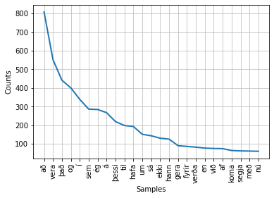

```python
words = []

for file in get_random_sample(15):
    words.extend(extract_words(file)[1])

fq = FreqDist(word.lower() for word in words)
fq.plot(25, cumulative=False)
```

Visualizing the same data but with using the logarithm of the occurrences, this should ideally obtain a straight line:

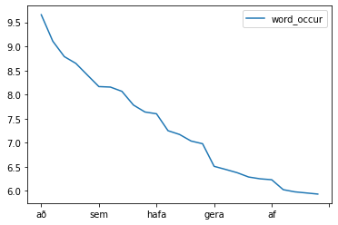

```python
freq_df = pd.DataFrame.from_dict(fq, orient='index', columns=['word_occur'])
freq_df.sort_values(by='word_occur', inplace=True, ascending=False)
freq_df.word_occur = np.log2(freq_df['word_occur'])
freq_df.head(25).plot(kind='line')
```

### Disappearing words / new words

```python
words_1914 = []
words_2014 = []

for file in get_files_for_year(1914, 25):
    words_1914.extend(extract_words(file)[1])

for file in get_files_for_year(2014, 25):
    words_2014.extend(extract_words(file)[1])
```

### Development of average sentence length

This is just one possible metric for the development/analysis of language complexity. There is so much more you could come up with here.

Obviously our choice to discard very short sentences in the preprocessing step has an impact on the values here:

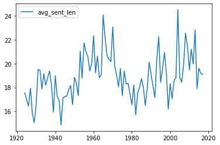

```python
def avg_sentence_length_year(year, k):
    sentence_len = []
    for file in get_files_for_year(year, k):
        sentences = extract_sentences(file)
        sentence_len.extend([len(s) for s in sentences])

    return reduce(lambda a, b: a + b, sentence_len) / len(sentence_len)

sentence_len_years = []

for year in range(1924, 2018):
    sentence_len_years.append(avg_sentence_length_year(year, 20))

avg_df = pd.DataFrame(sentence_len_years, index=range(1924, 2018), columns=['avg_sent_len'])
avg_df.plot(kind='line')
```

### n-grams

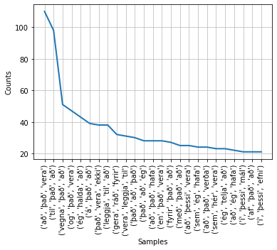

```python
def most_common_ngrams(n, top_k, sample):
    file_contents = []

    for file in get_random_sample(sample):
        file_contents.extend(extract_words(file)[1])

    fq_ngr = FreqDist(ngrams(file_contents, n))
    fq_ngr.plot(top_k, cumulative=False)

most_common_ngrams(n=3, top_k=25, sample=100)
```

## Building model for classifying speeches

The idea of this section is as follows:

- Import necessary libraries for the implementation of the next steps.
- Split the data in two sets: training and test.
- Select feature extraction methods to be used.
- Select classifiers to be trained.
- Train the classifiers using different feature extraction methods and different combination of hyperparameters within the classifiers. Perform a cross-validated grid search for that purpose.
- Compare the cross validation results within the trained models and select the best ones.

### Constructing training and test data

⚠️ *So far, we don't have a defined strategy for train-test split. However, we extract some documents to be able to try the models.*

⚠️ *We will have to design an appropiate strategy for a train-test split in which we shpuld keep the proportions within each class and so on.*

#### Train data

```python
#set seed for reproducibility
random.seed(123)

file_contents = []
targets = []

#for year in [1914, 1933,1959,1968,1971,1984,1997,2005,  2016]:
#    for file in get_files_for_year(year, 20):
for year in [1914, 1912,
             1933, 1936, 1939, 1938, 1934,
             1954, 1955, 1957, 1959, 1956,
             1975, 1978, 1972, 1971, 1977,
             1992, 1995, 1999, 1997, 1993,
             2014, 2015, 2013, 2016, 2012]:
    for file in get_files_for_year(year, 200):
        file_contents.append(extract_words(file)[1])
        targets.append(year - year%10)
```

#### Test data

```python
#seed for reproducibility
random.seed(123)

file_contents_test = []
targets_test = []

#for year in [1914, 1936, 1955, 1975, 1995, 2015]:
for year in [1911, 1937, 1958, 1973, 1994, 2017]:
    for file in get_files_for_year(year, 50):
        file_contents_test.append(extract_words(file)[1])
        targets_test.append(year - year%10)
```

### Text feature extraction

#### TF-IDF

Helper function to transform the data so that it is in the right format for the tfidfVectorizer() function that will be used later on:

```python
class JoinElement(object):
    def fit(self, X, y):
        return self

    def transform(self, X):
        #joins the elements of a list (which represents a document) into a single string
        #with a blank space separation between each word
        return [' '.join(X[i]) for i in range(len(X))]
```

More information about it: [sklearn documentation.](https://scikit-learn.org/stable/modules/generated/sklearn.naive_bayes.MultinomialNB.html)

#### Word2Vec

Original paper: Mikolov, T., Sutskever, I., Chen, K., Corrado, G. S., & Dean, J. (2013). Distributed representations of words and phrases and their compositionality. Advances in neural information processing systems, 26, 3111-3119.

With this model every word is assigned a unique vector of configurable cardinality such that the dot product of two randomly chosen vectors should be proportional to the semantic similarity for the associated words. This happens during the training step using logistic regression and sliding windows. Personally I found that this video delivers a solid explanation of the concepts: https://www.youtube.com/watch?v=QyrUentbkvw

However, since we are working with entire documents as training items we have to somehow aggregate the vectors for every word in a given document. This can be done e.g. by taking the mean and/or summing up the vectors (see `MeanEmbeddingVectorizer`), optionally weighted by TF-IDF (see `MeanEmbeddingVectorizerTfidf`).

```python
class MeanEmbeddingVectorizer(BaseEstimator):
    def fit(self, X, y):
        self.word2vec = Word2Vec(X)
        return self

    def transform(self, X):
        return np.array([
            np.mean([self.word2vec.wv[w] for w in words if w in self.word2vec.wv.vocab]
                    or [np.zeros(self.word2vec.vector_size)], axis=0)
            for words in X
        ])

    def fit_transform(self, X, y):
        self.fit(X, y)
        return self.transform(X)
```

```python
class MeanEmbeddingVectorizerTfidf(BaseEstimator):
    def fit(self, X, y):
        self.word2vec = Word2Vec(X)
        self.X_joined = [' '.join(X[i]) for i in range(len(X))]
        self.vectorizer = TfidfVectorizer()
        self.transformed = self.vectorizer.fit_transform(self.X_joined)
        self.transformed = pd.DataFrame.sparse.from_spmatrix(self.transformed)
        return self

    def tfidf(self, w, docid):
        if w in self.vectorizer.vocabulary_:
            return self.transformed[self.vectorizer.vocabulary_[w]][docid]
        else:
            return 0

    def transform(self, X):
        return np.array([
            np.mean([self.word2vec.wv[w] * self.tfidf(w, i) for w in words if w in self.word2vec.wv.vocab]
                    or [np.zeros(self.word2vec.vector_size)], axis=0)
            for i, words in enumerate(X)
        ])

    def fit_transform(self, X, y):
        self = self.fit(X, y)
        return self.transform(X)
```

#### Doc2Vec

Finally we are attempting to build a model using *Doc2Vec*. After training this model with our training corpus we receive a vector of configurable cardinality for each document.

Original paper: Le, Quoc, and Tomas Mikolov. "Distributed representations of sentences and documents." International conference on machine learning. 2014.

```python
class Doc2Vectorizer(BaseEstimator):
    def __init__(self, window=2, vector_size=100):
        self.window = window
        self.vector_size = vector_size

    def fit(self, X, y):
        docs = [TaggedDocument(X[i], [y[i]]) for i in range(len(X))]
        self.doc_vec = Doc2Vec(docs, vector_size=self.vector_size, window=self.window, min_count=1, workers=4)
        return self

    def transform(self, X):
        return [self.doc_vec.infer_vector(X[i]) for i in range(len(X))]
```

**BERT** (*Bidirectional Encoder Representations from Transformers*) is also interesting to look at, but we'll skip this here because we predict training a model from scratch would use up too many resources. Given more time however you could search for pretrained networks that roughly serve the purpose of classification of documents according to publication year.

Paper: Devlin, J., Chang, M. W., Lee, K., & Toutanova, K. (2018). Bert: Pre-training of deep bidirectional transformers for language understanding. arXiv preprint arXiv:1810.04805.

### Classifiers

3 different classifiers are going to be trained: Multinomial Naive Bayes, Support Vector Machines and Random Forest Classifier. All of them will be implemented using sklearn library.

#### Multinominal Naive Bayes

Source: [sklearn documentation.](https://scikit-learn.org/stable/modules/generated/sklearn.naive_bayes.MultinomialNB.html)

### Train models

Since there are 3 methods for feature extraction and 3 classifiers, we should train 9 kind of models with their different combinations of hyperparameters. However, multinomial naive bayes does not take negative values produced by Word2Vec and Doc2Vec. Therefore, we have 7.

For each model, a grid search is performed with different combinations of hyperparameters for the classifiers and the text extraction methods. Afterwards, the most relevant results of each of the models are stored in a pandas data frame.

#### Model 1: TFIDF vectorizer, select K best and Multinomial Naive Bayes

```python
#choose parameters for the different steps in the pipeline
parameters_model_1 = {

    #select KBest
    "k_best__k": [1000],
    "k_best__score_func": [chi2],

    #MultinomialNaiveBayes
    "MNB__alpha" : [0,0.05,0.1,0.5,1],
    "MNB__fit_prior": [True,False]

}


#build a pipeline
model_1_pipeline = Pipeline([
        #joins list into a single string
        ('join', JoinElement()),
        #tfidf vectorizer
        ('tfidf', TfidfVectorizer()),
        #select 1000 best from word vectors
        ('k_best', SelectKBest()),
        #apply naive bayes
        ('MNB', MultinomialNB())
    ])

#design grid search
grid_search_model_1 = GridSearchCV(
    #pipeline to be followed
    model_1_pipeline,
    #parameters
    param_grid=parameters_model_1,
    #number of folds for CV
    cv=5,
    #scoring to be considered for the cv
    scoring = "accuracy",
    #parallelize if possible
    n_jobs=-1
)

#fit the grid search for training data
grid_search_model_1.fit(file_contents, targets)

#save results of cross validation
cv_results_model_1 = pd.DataFrame(grid_search_model_1.cv_results_)

#filter columns to be kept in the dataframe
filter_col = [col for col in cv_results_model_1 if (col.startswith("param_") or col.startswith("mean_") or col.startswith("rank"))]

#save results with only filtered columns
cv_results_model_1 = cv_results_model_1[filter_col]

#save name of the model for later comparison
cv_results_model_1.insert(loc=0, column="Model", value= "1")

#round mean_test_score
cv_results_model_1["mean_test_score"] = cv_results_model_1["mean_test_score"].round(2)

#show best 5 sorted by mean_test_score
display(cv_results_model_1.sort_values(by="mean_test_score", ascending=False).head(5))
```

|  | Model | mean_fit_time | mean_score_time | param_MNB__alpha | param_MNB__fit_prior | param_k_best__k | param_k_best__score_func | mean_test_score | rank_test_score |
| --- | --- | --- | --- | --- | --- | --- | --- | --- | --- |
| 1 | 1 | 1.524927 | 0.331172 | 0 | False | 1000 | <function chi2 at 0x7fbbdbf5dc10> | 0.82 | 1 |
| 3 | 1 | 1.391712 | 0.330401 | 0.05 | False | 1000 | <function chi2 at 0x7fbbdbf5dc10> | 0.82 | 2 |
| 5 | 1 | 1.407895 | 0.342288 | 0.1 | False | 1000 | <function chi2 at 0x7fbbdbf5dc10> | 0.81 | 3 |
| 0 | 1 | 1.444507 | 0.329906 | 0 | True | 1000 | <function chi2 at 0x7fbbdbf5dc10> | 0.80 | 4 |
| 2 | 1 | 1.401343 | 0.336928 | 0.05 | True | 1000 | <function chi2 at 0x7fbbdbf5dc10> | 0.78 | 5 |

#### Model 2: TFIDF vectorizer, select K best and SVC

```python
#choose parameters for the different steps in the pipeline
parameters_model_2 = {

    #select KBest
    "k_best__k": [1000],
    "k_best__score_func": [chi2],

    #SVC
    "SVC__kernel" : ["linear", "poly", "sigmoid"],
    "SVC__degree": [2,3]

}


#build a pipeline
model_2_pipeline = Pipeline([
        #joins list into a single string
        ('join', JoinElement()),
        #tfidf vectorizer
        ('tfidf', TfidfVectorizer()),
        #select 1000 best from word vectors
        ('k_best', SelectKBest()),
        #apply naive bayes
        ('SVC', SVC())
    ])

#design grid search
grid_search_model_2 = GridSearchCV(
    #pipeline to be followed
    model_2_pipeline,
    #parameters
    param_grid=parameters_model_2,
    #number of folds for CV
    cv=5,
    #scoring to be considered for the cv
    scoring = "accuracy",
    #parallelize if possible
    n_jobs=-1
)

#fit the grid search for training data
grid_search_model_2.fit(file_contents, targets)

#save results of cross validation
cv_results_model_2 = pd.DataFrame(grid_search_model_2.cv_results_)

#filter columns to be kept in the dataframe
filter_col = [col for col in cv_results_model_2 if (col.startswith("param_") or col.startswith("mean_") or col.startswith("rank"))]

#save results with only filtered columns
cv_results_model_2 = cv_results_model_2[filter_col]

#save name of the model for later comparison
cv_results_model_2.insert(loc=0, column="Model", value= "2")

#round mean_test_score
cv_results_model_2["mean_test_score"] = cv_results_model_2["mean_test_score"].round(2)

#show best 5 sorted by mean_test_score
display(cv_results_model_2.sort_values(by="mean_test_score", ascending=False).head(5))
```

|  | Model | mean_fit_time | mean_score_time | param_SVC__degree | param_SVC__kernel | param_k_best__k | param_k_best__score_func | mean_test_score | rank_test_score |
| --- | --- | --- | --- | --- | --- | --- | --- | --- | --- |
| 1 | 2 | 5.597282 | 1.432608 | 2 | poly | 1000 | <function chi2 at 0x7fbbdbf5dc10> | 0.78 | 1 |
| 0 | 2 | 5.205752 | 1.409004 | 2 | linear | 1000 | <function chi2 at 0x7fbbdbf5dc10> | 0.75 | 2 |
| 3 | 2 | 6.459674 | 1.811362 | 3 | linear | 1000 | <function chi2 at 0x7fbbdbf5dc10> | 0.75 | 2 |
| 4 | 2 | 6.378722 | 1.368371 | 3 | poly | 1000 | <function chi2 at 0x7fbbdbf5dc10> | 0.73 | 4 |
| 2 | 2 | 5.524270 | 1.345796 | 2 | sigmoid | 1000 | <function chi2 at 0x7fbbdbf5dc10> | 0.55 | 5 |

#### Model 3: TFIDF vectorizer, select K best and Random Forest Classifier

```python
#choose parameters for the different steps in the pipeline
parameters_model_3 = {

    #select KBest
    "k_best__k": [1000],
    "k_best__score_func": [chi2],

    #RF classifier
    "clf__n_estimators" : [10,100,200,300]

}


#build a pipeline
model_3_pipeline = Pipeline([
        #joins list into a single string
        ('join', JoinElement()),
        #tfidf vectorizer
        ('tfidf', TfidfVectorizer()),
        #select 1000 best from word vectors
        ('k_best', SelectKBest()),
        #apply naive bayes
        ('clf', RandomForestClassifier())
    ])

#design grid search
grid_search_model_3 = GridSearchCV(
    #pipeline to be followed
    model_3_pipeline,
    #parameters
    param_grid=parameters_model_3,
    #number of folds for CV
    cv=5,
    #scoring to be considered for the cv
    scoring = "accuracy",
    #parallelize if possible
    n_jobs=-1
)

#fit the grid search for training data
grid_search_model_3.fit(file_contents, targets)

#save results of cross validation
cv_results_model_3 = pd.DataFrame(grid_search_model_3.cv_results_)

#filter columns to be kept in the dataframe
filter_col = [col for col in cv_results_model_3 if (col.startswith("param_") or col.startswith("mean_") or col.startswith("rank"))]

#save results with only filtered columns
cv_results_model_3 = cv_results_model_3[filter_col]

#save name of the model for later comparison
cv_results_model_3.insert(loc=0, column="Model", value= "3")

#round mean_test_score
cv_results_model_3["mean_test_score"] = cv_results_model_3["mean_test_score"].round(2)

#show best 5 sorted by mean_test_score
display(cv_results_model_3.sort_values(by="mean_test_score", ascending=False).head(5))
```

|  | Model | mean_fit_time | mean_score_time | param_clf__n_estimators | param_k_best__k | param_k_best__score_func | mean_test_score | rank_test_score |
| --- | --- | --- | --- | --- | --- | --- | --- | --- |
| 2 | 3 | 6.932103 | 0.480441 | 200 | 1000 | <function chi2 at 0x7fbbdbf5dc10> | 0.73 | 1 |
| 3 | 3 | 8.926858 | 0.383013 | 300 | 1000 | <function chi2 at 0x7fbbdbf5dc10> | 0.73 | 2 |
| 1 | 3 | 3.773559 | 0.393197 | 100 | 1000 | <function chi2 at 0x7fbbdbf5dc10> | 0.72 | 3 |
| 0 | 3 | 1.563078 | 0.324162 | 10 | 1000 | <function chi2 at 0x7fbbdbf5dc10> | 0.62 | 4 |

#### Model 4: Word2Vec and SVC

```python
#choose parameters for the different steps in the pipeline
parameters_model_4 = {

    #SVC
    "SVC__kernel" : ["linear", "poly", "sigmoid"],
    "SVC__degree": [2,3]

}


#build a pipeline
model_4_pipeline = Pipeline([
        #tfidf vectorizer
        ('word2vec', MeanEmbeddingVectorizer()),
        #apply naive bayes
        ('SVC', SVC())
    ])

#design grid search
grid_search_model_4 = GridSearchCV(
    #pipeline to be followed
    model_4_pipeline,
    #parameters
    param_grid=parameters_model_4,
    #number of folds for CV
    cv=5,
    #scoring to be considered for the cv
    scoring = "accuracy",
    #parallelize if possible
    n_jobs=-1
)

#fit the grid search for training data
grid_search_model_4.fit(file_contents, targets)

#save results of cross validation
cv_results_model_4 = pd.DataFrame(grid_search_model_4.cv_results_)

#filter columns to be kept in the dataframe
filter_col = [col for col in cv_results_model_4 if (col.startswith("param_") or col.startswith("mean_") or col.startswith("rank"))]

#save results with only filtered columns
cv_results_model_4 = cv_results_model_4[filter_col]

#save name of the model for later comparison
cv_results_model_4.insert(loc=0, column="Model", value= "4")

#round mean_test_score
cv_results_model_4["mean_test_score"] = cv_results_model_4["mean_test_score"].round(2)

#show best 5 sorted by mean_test_score
display(cv_results_model_4.sort_values(by="mean_test_score", ascending=False).head(5))
```

|  | Model | mean_fit_time | mean_score_time | param_SVC__degree | param_SVC__kernel | mean_test_score | rank_test_score |
| --- | --- | --- | --- | --- | --- | --- | --- |
| 0 | 4 | 33.631611 | 2.571135 | 2 | linear | 0.54 | 1 |
| 3 | 4 | 38.590638 | 2.533163 | 3 | linear | 0.53 | 2 |
| 4 | 4 | 36.673138 | 2.196457 | 3 | poly | 0.49 | 3 |
| 1 | 4 | 38.521074 | 2.761024 | 2 | poly | 0.46 | 4 |
| 2 | 4 | 40.036771 | 2.953432 | 2 | sigmoid | 0.39 | 5 |

#### Model 5: Word2Vec and Random Forest Classifier

```python
#choose parameters for the different steps in the pipeline
parameters_model_5 = {

    #RF classifier
    "clf__n_estimators" : [10,100,200,300]

}


#build a pipeline
model_5_pipeline = Pipeline([
        #tfidf vectorizer
        ('word2vec', MeanEmbeddingVectorizer()),
        #apply naive bayes
        ('clf', RandomForestClassifier())
    ])

#design grid search
grid_search_model_5 = GridSearchCV(
    #pipeline to be followed
    model_5_pipeline,
    #parameters
    param_grid=parameters_model_5,
    #number of folds for CV
    cv=5,
    #scoring to be considered for the cv
    scoring = "accuracy",
    #parallelize if possible
    n_jobs=-1
)

#fit the grid search for training data
grid_search_model_5.fit(file_contents, targets)

#save results of cross validation
cv_results_model_5 = pd.DataFrame(grid_search_model_5.cv_results_)

#filter columns to be kept in the dataframe
filter_col = [col for col in cv_results_model_5 if (col.startswith("param_") or col.startswith("mean_") or col.startswith("rank"))]

#save results with only filtered columns
cv_results_model_5 = cv_results_model_5[filter_col]

#save name of the model for later comparison
cv_results_model_5.insert(loc=0, column="Model", value= "5")

#round mean_test_score
cv_results_model_5["mean_test_score"] = cv_results_model_5["mean_test_score"].round(2)

#show best 5 sorted by mean_test_score
display(cv_results_model_5.sort_values(by="mean_test_score", ascending=False).head(5))
```

|  | Model | mean_fit_time | mean_score_time | param_clf__n_estimators | mean_test_score | rank_test_score |
| --- | --- | --- | --- | --- | --- | --- |
| 2 | 5 | 41.454146 | 1.613599 | 200 | 0.47 | 2 |
| 3 | 5 | 34.221691 | 0.899461 | 300 | 0.47 | 1 |
| 1 | 5 | 41.179541 | 2.397368 | 100 | 0.46 | 3 |
| 0 | 5 | 33.133284 | 2.269344 | 10 | 0.37 | 4 |